# Correlation And Regression Homework

Kelly Luis

Note: Datasets are available at http://whitlockschluter.zoology.ubc.ca/data so you don’t have to type anything in (and have to load it!)

## 1. Correlation - W&S Chapter 16

### Questions 15

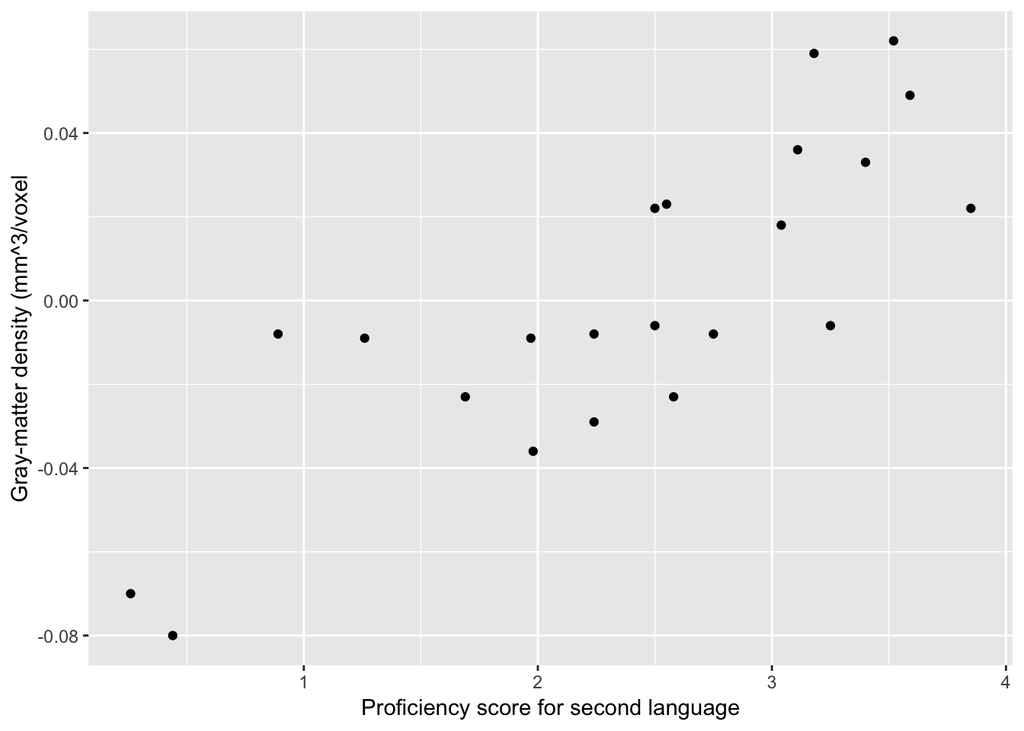

```r
# Download Data
gray <- read.csv(url("http://www.zoology.ubc.ca/~schluter/WhitlockSchluter/wp-content/data/chapter16/chap16q15LanguageGreyMatter.csv"))

# A. Display association between the two variables in a scatter plot
ggplot(data = gray, aes(x=proficiency, y=greymatter)) +
  geom_point() +
  xlab("Proficiency score for second language") +
  ylab("Gray-matter density (mm^3/voxel")
```

```r
# B. Calculate the correlation between second language proficiency and gray matter density
grayCor <- cor.test(gray$greymatter,gray$proficiency)
grayCor$estimate
```

```
##       cor
## 0.8183134
```

C. Test the null hypothesis We can reject the null hypothesis because the correlation coefficient is greater than 0 (0.8183134).

D. What are you assumptions for part c? 1) Random Sample from a Normal Population 2) Bivariate Normal Distribution - Bell shaped normal distribution in two dimensions

E. Does the scatter plot support these assumptions? The scatter plot indicates a bivariate normal distribution where the relationship between X and Y is linear, cloud of points have a ellipitcal shape, and the frequency distribution of X and Y separately appear normal